# Mathematics for Data Science I

## 3. Using PageRank to answer questions

Now that we've seen a bit more of list comprehension, let's use it to help us do some data science. First let's set some context.

*It's 1994, you're working from the United Nations. Your boss walks into the room and say there's a trade war going on. We need to know who is the most important country in the network of world trade. It's your job to find out.*

```python
import urllib, numpy as np
```

```python
response = urllib.request.urlopen("http://moreno.ss.uci.edu/trade.dat")
lines = [line[:-2].decode() for line in response.readlines()]
countries = lines[5:29]
matrix = lines[61:85]
```

Let's have a look at the variable matrix.

```python
matrix
```

```
[' 0 0 0 1 1 0 0 0 0 0 0 0 1 0 0 0 0 0 0 0 0 0 0 1',
 ' 1 0 1 1 0 1 0 0 1 0 1 1 1 0 0 0 1 1 1 0 1 0 1 0',
 ' 1 1 0 1 1 1 1 0 1 1 1 1 1 1 0 1 1 1 1 1 1 1 1 1',
 ' 1 1 1 0 1 0 1 1 1 1 1 0 1 1 1 1 1 1 1 1 1 1 1 1',
 ' 1 1 1 1 0 1 1 1 1 1 1 0 1 1 0 1 1 1 1 1 1 1 1 1',
 ' 0 0 1 0 0 0 0 0 0 0 0 0 0 0 0 0 0 0 0 0 0 0 1 0',
 ' 0 0 0 0 1 0 0 1 1 0 0 0 1 0 0 0 0 1 1 0 0 1 1 1',
 ' 0 0 0 0 0 0 0 0 0 0 0 0 0 0 0 0 0 1 0 0 0 1 0 0',
 ' 1 1 1 1 1 1 1 1 0 1 1 1 1 0 0 1 1 1 1 1 1 1 1 1',
 ' 0 0 0 0 0 0 0 0 0 0 0 0 0 0 0 0 0 0 0 0 0 0 1 0',
 ' 1 0 0 1 1 0 1 0 1 0 0 0 1 0 0 1 1 1 1 0 1 1 1 1',
 ' 0 1 0 0 0 0 0 1 1 0 0 0 1 0 0 1 0 1 1 0 1 1 1 1',
 ' 1 1 1 1 1 1 1 1 1 1 1 1 0 1 1 1 1 1 1 1 1 1 1 1',
 ' 0 0 0 0 0 0 0 0 0 0 0 0 0 0 0 0 0 0 0 0 0 0 0 0',
 ' 0 0 0 0 0 0 0 0 0 0 0 0 0 0 0 0 0 0 0 0 0 1 0 0',
 ' 1 0 0 1 0 0 1 0 0 0 1 0 1 0 0 0 1 1 0 0 1 1 1 1',
 ' 0 0 0 1 1 0 0 0 1 0 1 0 1 1 0 1 0 1 1 1 1 1 1 0',
 ' 1 1 1 1 1 1 1 0 1 1 1 1 1 1 1 1 1 0 1 1 1 1 1 1',
 ' 1 1 1 1 1 1 1 1 1 1 1 1 1 1 1 1 1 1 0 1 1 1 1 1',
 ' 0 0 0 0 0 0 0 0 0 0 0 0 0 0 0 0 0 0 0 0 0 0 0 0',
 ' 0 0 1 1 0 0 0 0 1 0 1 1 1 0 0 1 1 1 1 1 0 1 1 1',
 ' 1 0 1 1 1 1 1 1 1 1 1 1 1 1 1 1 1 1 1 1 1 0 1 1',
 ' 1 1 1 1 1 1 1 1 1 1 1 1 1 1 1 1 1 1 1 1 1 1 0 1',
 ' 1 1 0 1 1 0 1 1 1 0 1 1 1 0 0 1 1 1 1 1 1 1 1 0']
```

It appears to be an array of strings. We want it to be an array of arrays. Use some of your new **list comprehension skills** to convert each row of the matrix to an array of integers. Hint: you can use `.split()` on a string to spit it up into a list, and then turn each little string into a number using `int()`.

```python
# Challenge: Turn the row of strings into a row of integers.

def row_function(row):
    return [int(i) for i in row.split()]

fixed_matrix = [row_function(row) for row in matrix]
fixed_matrix
```

```
[[0, 0, 0, 1, 1, 0, 0, 0, 0, 0, 0, 0, 1, 0, 0, 0, 0, 0, 0, 0, 0, 0, 0, 1],
 [1, 0, 1, 1, 0, 1, 0, 0, 1, 0, 1, 1, 1, 0, 0, 0, 1, 1, 1, 0, 1, 0, 1, 0],
 [1, 1, 0, 1, 1, 1, 1, 0, 1, 1, 1, 1, 1, 1, 0, 1, 1, 1, 1, 1, 1, 1, 1, 1],
 [1, 1, 1, 0, 1, 0, 1, 1, 1, 1, 1, 0, 1, 1, 1, 1, 1, 1, 1, 1, 1, 1, 1, 1],
 [1, 1, 1, 1, 0, 1, 1, 1, 1, 1, 1, 0, 1, 1, 0, 1, 1, 1, 1, 1, 1, 1, 1, 1],
 [0, 0, 1, 0, 0, 0, 0, 0, 0, 0, 0, 0, 0, 0, 0, 0, 0, 0, 0, 0, 0, 0, 1, 0],
 [0, 0, 0, 0, 1, 0, 0, 1, 1, 0, 0, 0, 1, 0, 0, 0, 0, 1, 1, 0, 0, 1, 1, 1],
 [0, 0, 0, 0, 0, 0, 0, 0, 0, 0, 0, 0, 0, 0, 0, 0, 0, 1, 0, 0, 0, 1, 0, 0],
 [1, 1, 1, 1, 1, 1, 1, 1, 0, 1, 1, 1, 1, 0, 0, 1, 1, 1, 1, 1, 1, 1, 1, 1],
 [0, 0, 0, 0, 0, 0, 0, 0, 0, 0, 0, 0, 0, 0, 0, 0, 0, 0, 0, 0, 0, 0, 1, 0],
 [1, 0, 0, 1, 1, 0, 1, 0, 1, 0, 0, 0, 1, 0, 0, 1, 1, 1, 1, 0, 1, 1, 1, 1],
 [0, 1, 0, 0, 0, 0, 0, 1, 1, 0, 0, 0, 1, 0, 0, 1, 0, 1, 1, 0, 1, 1, 1, 1],
 [1, 1, 1, 1, 1, 1, 1, 1, 1, 1, 1, 1, 0, 1, 1, 1, 1, 1, 1, 1, 1, 1, 1, 1],
 [0, 0, 0, 0, 0, 0, 0, 0, 0, 0, 0, 0, 0, 0, 0, 0, 0, 0, 0, 0, 0, 0, 0, 0],
 [0, 0, 0, 0, 0, 0, 0, 0, 0, 0, 0, 0, 0, 0, 0, 0, 0, 0, 0, 0, 0, 1, 0, 0],
 [1, 0, 0, 1, 0, 0, 1, 0, 0, 0, 1, 0, 1, 0, 0, 0, 1, 1, 0, 0, 1, 1, 1, 1],
 [0, 0, 0, 1, 1, 0, 0, 0, 1, 0, 1, 0, 1, 1, 0, 1, 0, 1, 1, 1, 1, 1, 1, 0],
 [1, 1, 1, 1, 1, 1, 1, 0, 1, 1, 1, 1, 1, 1, 1, 1, 1, 0, 1, 1, 1, 1, 1, 1],
 [1, 1, 1, 1, 1, 1, 1, 1, 1, 1, 1, 1, 1, 1, 1, 1, 1, 1, 0, 1, 1, 1, 1, 1],
 [0, 0, 0, 0, 0, 0, 0, 0, 0, 0, 0, 0, 0, 0, 0, 0, 0, 0, 0, 0, 0, 0, 0, 0],
 [0, 0, 1, 1, 0, 0, 0, 0, 1, 0, 1, 1, 1, 0, 0, 1, 1, 1, 1, 1, 0, 1, 1, 1],
 [1, 0, 1, 1, 1, 1, 1, 1, 1, 1, 1, 1, 1, 1, 1, 1, 1, 1, 1, 1, 1, 0, 1, 1],
 [1, 1, 1, 1, 1, 1, 1, 1, 1, 1, 1, 1, 1, 1, 1, 1, 1, 1, 1, 1, 1, 1, 0, 1],
 [1, 1, 0, 1, 1, 0, 1, 1, 1, 0, 1, 1, 1, 0, 0, 1, 1, 1, 1, 1, 1, 1, 1, 0]]
```

Once that is fixed we can turn this list of lists into our friendly numpy array, and calculate the PageRank. If you've forgotten, check out [the MyUni Page](https://myuni.adelaide.edu.au/courses/54098/pages/week-9-application-eigenvectors-and-pagerank?module_item_id=1980152).

```python
M = np.array(fixed_matrix)
M = M / M.sum(axis = 0)
```

```python
results = np.linalg.eig(M)
eigenvector = results[1][:,0].real # We sift through the results to find the eigenvector we want
```

Well that was a lot faster than finding the row reduced echelon form. But what does it actually mean? The value for each country in `countries` will have a corresponding element in the `eigenvector`. Not much help until we visualize it!

(What is an *eigenvector* and why is it coming up here? Recall, that the PageRank algorithm solves the equation $A \mathbf x = \mathbf x$ (for some non-zero vector $\mathbf x$). This is an example of an *eigenvector equation*, which will will learn more about in Section 5. It turns out that `np.linalg.solve` does not like to solve these kinds of equations (with infinitely many solutions), **but** there is an *inbuilt* solver in this case, which uses the fact that these are eigenvectors. Excellent!)

To answer the question, let's try to make a *bar chart* of the countries and their PageRank score! Then you can write down who is the most important to global trade. Hint: `plt.xticks(rotation=90)` might be handy!

```
([0,
  1,
  2,
  3,
  4,
  5,
  6,
  7,
  8,
  9,
  10,
  11,
  12,
  13,
  14,
  15,
  16,
  17,
  18,
  19,
  20,
  21,
  22,
  23],
 <a list of 24 Text major ticklabel objects>)
```

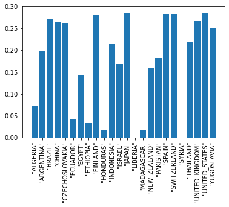

```python
import matplotlib.pyplot as plt
plt.bar(countries, eigenvector)
plt.xticks(rotation=90)
```

As a little extension we can load it into a special python networks package called **networkx**. With this we can can calculate the **PageRank** super easily. As well as being easy, the PageRank algorithms in networkx are super fast! It's often better to use algorithms that have been optimized by others and then build on top of them yourself. This is the core idea behind open source development.

Try to figure out how to take the graph G and calculate the PageRank using networkx. Is it the same? If no, figure out why? Maybe even try visualising the network!

```python
import networkx as nx
G = nx.from_numpy_array(M)
```

```python
nx.pagerank(G)
```

```
{0: 0.03154157252601277,
 1: 0.04197230683787692,
 2: 0.05420201554414406,
 3: 0.050940241815642016,
 4: 0.05178817254759086,
 5: 0.030775743085311825,
 6: 0.03401599663703164,
 7: 0.03306784520093294,
 8: 0.048651806834926654,
 9: 0.031232543619954572,
 10: 0.035779951702608837,
 11: 0.03517998443825416,
 12: 0.055325825351361234,
 13: 0.03134645222533108,
 14: 0.031207302838028292,
 15: 0.03549496348311635,
 16: 0.03639574884386426,
 17: 0.054895596544630255,
 18: 0.05679462987816731,
 19: 0.03151737060463699,
 20: 0.03536700045047845,
 21: 0.05383211480197084,
 22: 0.05631044982090039,
 23: 0.04236436436722708}
```